# Week 7

```python
from __future__ import print_function, division

%matplotlib inline

import numpy as np

import nsfg
import first
import analytic

import thinkstats2
import thinkplot
```

## Exponential distribution

Here's what the exponential CDF looks like with a range of parameters.

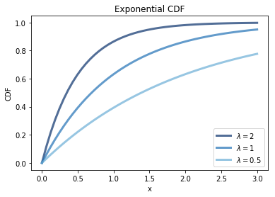

```python
thinkplot.PrePlot(3)
for lam in [2.0, 1, 0.5]:
    xs, ps = thinkstats2.RenderExpoCdf(lam, 0, 3.0, 50)
    label = r'$\lambda=%g$' % lam
    thinkplot.Plot(xs, ps, label=label)

thinkplot.Config(title='Exponential CDF', xlabel='x', ylabel='CDF',
                 loc='lower right')
```

Here's the distribution of interarrival times from a dataset of birth times.

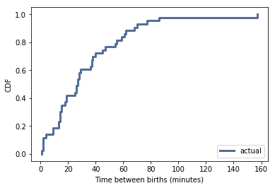

```python
df = analytic.ReadBabyBoom()
diffs = df.minutes.diff()
cdf = thinkstats2.Cdf(diffs, label='actual')

thinkplot.Cdf(cdf)
thinkplot.Config(xlabel='Time between births (minutes)', ylabel='CDF')
```

Here's what the CCDF looks like on a log-y scale. A straight line is consistent with an exponential distribution.

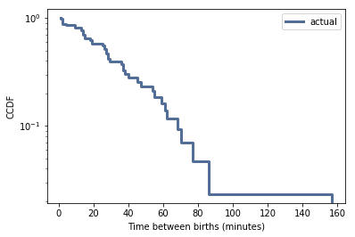

```python
thinkplot.Cdf(cdf, complement=True)
thinkplot.Config(xlabel='Time between births (minutes)',
                 ylabel='CCDF', yscale='log', loc='upper right')
```

## Normal distribution

Here's what the normal CDF looks like with a range of parameters.

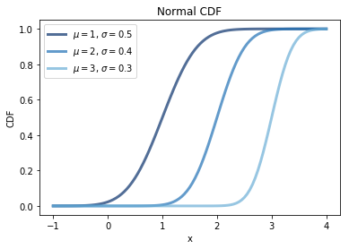

```python
thinkplot.PrePlot(3)

mus = [1.0, 2.0, 3.0]
sigmas = [0.5, 0.4, 0.3]
for mu, sigma in zip(mus, sigmas):
    xs, ps = thinkstats2.RenderNormalCdf(mu=mu, sigma=sigma,
                                               low=-1.0, high=4.0)
    label = r'$\mu=%g$, $\sigma=%g$' % (mu, sigma)
    thinkplot.Plot(xs, ps, label=label)

thinkplot.Config(title='Normal CDF', xlabel='x', ylabel='CDF',
                 loc='upper left')
```

I'll use a normal model to fit the distribution of birth weights from the NSFG.

```python
preg = nsfg.ReadFemPreg()
weights = preg.totalwgt_lb.dropna()
```

Here's the observed CDF and the model. The model fits the data well except in the left tail.

```
Mean, Var 7.280883100022579 1.5452125703544901
Sigma 1.2430657948614345
```

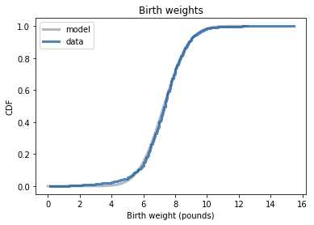

```python
# estimate parameters: trimming outliers yields a better fit
mu, var = thinkstats2.TrimmedMeanVar(weights, p=0.01)
print('Mean, Var', mu, var)

# plot the model
sigma = np.sqrt(var)
print('Sigma', sigma)
xs, ps = thinkstats2.RenderNormalCdf(mu, sigma, low=0, high=12.5)

thinkplot.Plot(xs, ps, label='model', color='0.6')

# plot the data
cdf = thinkstats2.Cdf(weights, label='data')

thinkplot.PrePlot(1)
thinkplot.Cdf(cdf)
thinkplot.Config(title='Birth weights',
                 xlabel='Birth weight (pounds)',
                 ylabel='CDF')
```

A normal probability plot is a visual test for normality. The following example shows that if the data are actually from a normal distribution, the plot is approximately straight.

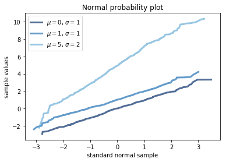

```python
n = 1000
thinkplot.PrePlot(3)

mus = [0, 1, 5]
sigmas = [1, 1, 2]

for mu, sigma in zip(mus, sigmas):
    sample = np.random.normal(mu, sigma, n)
    xs, ys = thinkstats2.NormalProbability(sample)
    label = '$\mu=%d$, $\sigma=%d$' % (mu, sigma)
    thinkplot.Plot(xs, ys, label=label)

thinkplot.Config(title='Normal probability plot',
                 xlabel='standard normal sample',
                 ylabel='sample values')
```

Here's the normal probability plot for birth weights, showing that the lightest babies are lighter than we expect from the normal mode, and the heaviest babies are heavier.

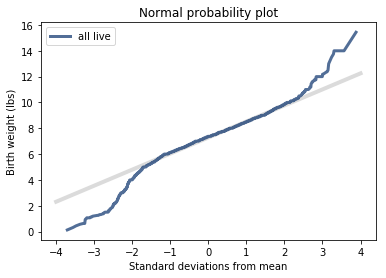

```python
mean, var = thinkstats2.TrimmedMeanVar(weights, p=0.01)
std = np.sqrt(var)

xs = [-4, 4]
fxs, fys = thinkstats2.FitLine(xs, mean, std)
thinkplot.Plot(fxs, fys, linewidth=4, color='0.8')

xs, ys = thinkstats2.NormalProbability(weights)
thinkplot.Plot(xs, ys, label='all live')

thinkplot.Config(title='Normal probability plot',
                 xlabel='Standard deviations from mean',
                 ylabel='Birth weight (lbs)')
```

If we suspect that the deviation in the left tail is due to preterm babies, we can check by selecting only full term births.

```python
full_term = preg[preg.prglngth >= 37]
term_weights = full_term.totalwgt_lb.dropna()
```

Now the deviation in the left tail is almost gone, but the heaviest babies are still heavy.

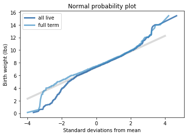

```python
mean, var = thinkstats2.TrimmedMeanVar(weights, p=0.01)
std = np.sqrt(var)

xs = [-4, 4]
fxs, fys = thinkstats2.FitLine(xs, mean, std)
thinkplot.Plot(fxs, fys, linewidth=4, color='0.8')

thinkplot.PrePlot(2)
xs, ys = thinkstats2.NormalProbability(weights)
thinkplot.Plot(xs, ys, label='all live')

xs, ys = thinkstats2.NormalProbability(term_weights)
thinkplot.Plot(xs, ys, label='full term')
thinkplot.Config(title='Normal probability plot',
                 xlabel='Standard deviations from mean',
                 ylabel='Birth weight (lbs)')
```

## Lognormal model

As an example of a lognormal disrtribution, we'll look at adult weights from the BRFSS.

```python
import brfss
df = brfss.ReadBrfss()
weights = df.wtkg2.dropna()
```

The following function estimates the parameters of a normal distribution and plots the data and a normal model.

```python
def MakeNormalModel(weights):
    """Plots a CDF with a Normal model.

    weights: sequence
    """
    cdf = thinkstats2.Cdf(weights, label='weights')

    mean, var = thinkstats2.TrimmedMeanVar(weights)
    std = np.sqrt(var)
    print('n, mean, std', len(weights), mean, std)

    xmin = mean - 4 * std
    xmax = mean + 4 * std

    xs, ps = thinkstats2.RenderNormalCdf(mean, std, xmin, xmax)
    thinkplot.Plot(xs, ps, label='model', linewidth=4, color='0.8')
    thinkplot.Cdf(cdf)
```

Here's the distribution of adult weights and a normal model, which is not a very good fit.

```
n, mean, std 398484 78.59599565702814 17.75455519179819
```

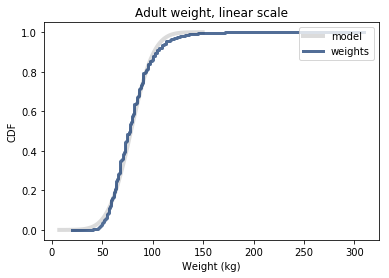

```python
MakeNormalModel(weights)
thinkplot.Config(title='Adult weight, linear scale', xlabel='Weight (kg)',
                 ylabel='CDF', loc='upper right')
```

Here's the distribution of adult weight and a lognormal model, plotted on a log-x scale. The model is a better fit for the data, although the heaviest people are heavier than the model expects.

```
n, mean, std 398484 1.884660713731975 0.096235802591517
```

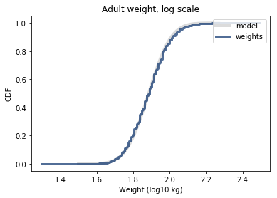

```python
log_weights = np.log10(weights)
MakeNormalModel(log_weights)
thinkplot.Config(title='Adult weight, log scale', xlabel='Weight (log10 kg)',
                 ylabel='CDF', loc='upper right')
```

The following function generates a normal probability plot.

```python
def MakeNormalPlot(weights):
    """Generates a normal probability plot of birth weights.

    weights: sequence
    """
    mean, var = thinkstats2.TrimmedMeanVar(weights, p=0.01)
    std = np.sqrt(var)

    xs = [-5, 5]
    xs, ys = thinkstats2.FitLine(xs, mean, std)
    thinkplot.Plot(xs, ys, color='0.8', label='model')

    xs, ys = thinkstats2.NormalProbability(weights)
    thinkplot.Plot(xs, ys, label='weights')
```

When we generate a normal probability plot with adult weights, we can see clearly that the data deviate from the model systematically.

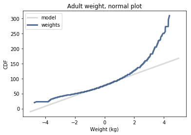

```python
MakeNormalPlot(weights)
thinkplot.Config(title='Adult weight, normal plot', xlabel='Weight (kg)',
                 ylabel='CDF', loc='upper left')
```

If we make a normal probability plot with log weights, the model fit the data well except in the tails, where the heaviest people exceed expectations.

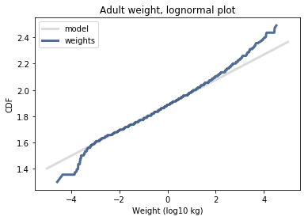

```python
MakeNormalPlot(log_weights)
thinkplot.Config(title='Adult weight, lognormal plot', xlabel='Weight (log10 kg)',
                 ylabel='CDF', loc='upper left')
```

## Pareto distribution

Here's what the Pareto CDF looks like with a range of parameters.

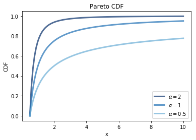

```python
xmin = 0.5

thinkplot.PrePlot(3)
for alpha in [2.0, 1.0, 0.5]:
    xs, ps = thinkstats2.RenderParetoCdf(xmin, alpha, 0, 10.0, n=100)
    thinkplot.Plot(xs, ps, label=r'$\alpha=%g$' % alpha)

thinkplot.Config(title='Pareto CDF', xlabel='x',
                 ylabel='CDF', loc='lower right')
```

The distribution of populations for cities and towns is sometimes said to be Pareto-like.

```python
import populations

pops = populations.ReadData()
print('Number of cities/towns', len(pops))
```

```
Number of cities/towns 19515
```

Here's the distribution of population for cities and towns in the U.S., along with a Pareto model. The model fits the data well in the tail.

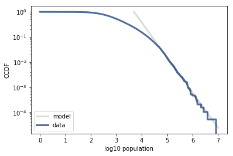

```python
log_pops = np.log10(pops)
cdf = thinkstats2.Cdf(pops, label='data')
cdf_log = thinkstats2.Cdf(log_pops, label='data')

# pareto plot
xs, ys = thinkstats2.RenderParetoCdf(xmin=5000, alpha=1.4, low=0, high=1e7)
thinkplot.Plot(np.log10(xs), 1-ys, label='model', color='0.8')

thinkplot.Cdf(cdf_log, complement=True)
thinkplot.Config(xlabel='log10 population',
                 ylabel='CCDF',
                 yscale='log', loc='lower left')
```

The lognormal model might be a better fit for this data (as is often the case for things that are supposed to be Pareto).

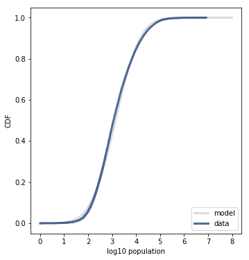

```python
thinkplot.PrePlot(cols=2)

mu, sigma = log_pops.mean(), log_pops.std()
xs, ps = thinkstats2.RenderNormalCdf(mu, sigma, low=0, high=8)
thinkplot.Plot(xs, ps, label='model', color='0.8')

thinkplot.Cdf(cdf_log)
thinkplot.Config(xlabel='log10 population',
                 ylabel='CDF', loc='lower right')
```

Here's a normal probability plot for the log-populations. The model fits the data well except in the right tail, where the biggest cities are bigger than expected.

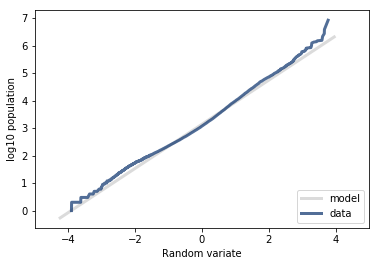

```python
thinkstats2.NormalProbabilityPlot(log_pops, label='data')
thinkplot.Config(xlabel='Random variate',
                 ylabel='log10 population',
                 xlim=[-5, 5])
```

## Random variates

When we have an analytic CDF, we can sometimes invert it to generate random values. The following function generates values from an exponential distribution.

```python
import random

def expovariate(lam):
    p = random.random()
    x = -np.log(1-p) / lam
    return x
```

We can test it by generating a sample.

```python
t = [expovariate(lam=2) for _ in range(1000)]
```

And plotting the CCDF on a log-y scale.

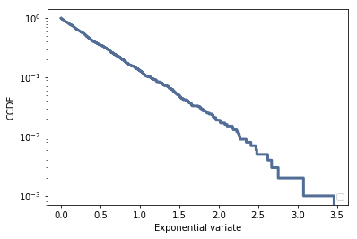

```python
cdf = thinkstats2.Cdf(t)

thinkplot.Cdf(cdf, complement=True)
thinkplot.Config(xlabel='Exponential variate', ylabel='CCDF', yscale='log')
```

A straight line is consistent with an exponential distribution.

As an exercise, write a function that generates a Pareto variate.

## Exercises

##### Exercise 1 Creating Normal distribution with PDF for Scipy

```python
from scipy.stats import norm,expon
import matplotlib.pyplot as plt
import numpy as np

# Generate an array of 200 random sample from a normal dist with
# mean 0 and stdv 1
random_sample = norm.rvs(loc=0,scale=1,size=200)
random_sample
```

[output not shown]

```python
# Distribution fitting
# norm.fit(data) returns a list of two parameters
# (mean, parameters[0] and std, parameters[1]) via a MLE approach
# to data, which should be in array form.
parameters = norm.fit(random_sample)
parameters
```

```
(-0.12219294932046264, 1.0540137874557072)
```

```python
# now, parameters[0] and parameters[1] are the mean and
# the standard deviation of the fitted distribution
x = np.linspace(-5,5,100)
x
```

[output not shown]

```python
# Generate the pdf (fitted distribution)
fitted_pdf = norm.pdf(x,loc = parameters[0],scale = parameters[1])
fitted_pdf
```

[output not shown]

```python
# Generate the pdf (normal distribution non fitted)
normal_pdf = norm.pdf(x)
fitted_pdf
```

[output not shown]

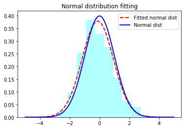

```python
# Type help(plot) for a ton of information on pyplot
plt.plot(x,fitted_pdf,"red",label="Fitted normal dist",linestyle="dashed", linewidth=2)
plt.plot(x,normal_pdf,"blue",label="Normal dist", linewidth=2)
plt.hist(random_sample,normed=1,color="cyan",alpha=.3) #alpha, from 0 (transparent) to 1 (opaque)
plt.title("Normal distribution fitting")
plt.legend()

plt.show()
```

##### Exercise 2 Take example above exercise 1 and do it yourself for exponential distribution with CDF

```python
#Solutions come here
```

# HomeWork-2 (Due Date 20.04.2018 23:59)

Read NSFG respondent data with .ReadFemResp() function that provided by nsfg.py and create a dataframe then assign it a variable that called resp.

- Split the respondents 2 dataframe according to her last completed education degree(column name is “hieduc”) give 1 dataframe as variable name “school” that respondents who are not finished any collage/university degree and give the variable name to other part as “university” whose are finished at least one collage degree . Give at least 5 descriptive statistics for ages of mothers at first birth (column name is “agemomb1”) each dataframe and explain it. To interpret the codes for hieduc column see the [This Link](https://www.icpsr.umich.edu/nsfg6/Controller?displayPage=labelDetails&fileCode=FEM§ion=R&subSec=7868&srtLabel=606811) (3 pts.)
- Plot both variable’s together in PMF and CDF. (2 pts.)
- For variables(“school” and “university”) that you have create above find the difference for ages of mothers at first birth(column name is “agemomb1”) in PMF and plot it. (2 pts.)
- With variables above, “school” and “university”, plot the CDF with ages of mothers at first birth(column name is “agemomb1”), then find probability of mothers who had first at less than 18 years old and also find the how much percentile of mothers are 18 and older than 18 years old.(2 pts.)
- Create any 2 distribution that you want with columns from resp dataframe and plot and explain meaning of plot, distribution and why you choose that column for that distribution.(3 pts)

  ##### Note that: There are 5 question and total of points is 12 but maximum points that can be get 10 points (2 points bonus). Do not forget the give the name to your visuals labels(visuals's label, x-axis and y-axis label), and width of the visuals' columns must be 0.5. In addition, Your answers/codes must be uploaded to your github accounts inside a folder that called Homework2_YourNameSurname. The due date is the end of the next Friday(20.04.2018 23:59). And you have to send me link of your github account via email again.

##### There will be no office hour for homeworks. The only chance in order to ask your questions about homework is 1 hour class time. If you have questions about homework you have to come 1 hour class in Tuesday

## ANY LATE UPLOAD TO GITHUB EVEN INCLUDING 1 MINUTE WILL NOT BE ACCEPTED AND HOMEWORKS HAVE TO BE UPLOADED TO ONLY GITHUB. JUST SEND ME YOUR GITHUB ACCOUNT LINK VIA EMAIL. FOR OTHER OPTIONS YOU HAVE TO TALK WITH ME.